# 01 report addition: Language detection task performed on sections

This notebook add results from the language detection made on the **section** level. Since only for the two newspapers sections were available, the results above cannot be direclty compared to the analysis above *(it is however possible to make a separate plot with the page-level language distribution in ekmteataja and livzeitung)*. Ten most common languages for sections are mostly the same as the ones detected on the page level, with higher level of error if section was too small.

| language | n_sections | percentage |
| --- | --- | --- |
| russian | 126937 | 56.84 |
| german | 83578 | 37.42 |
| ukrainian | 6257 | 2.80 |
| english | 1495 | 0.67 |
| estonian | 1299 | 0.58 |
| bulgarian | 1078 | 0.48 |
| middle_frisian | 886 | 0.40 |
| rumantsch | 305 | 0.14 |
| latvian | 290 | 0.13 |
| belarus | 276 | 0.12 |

Such unexpected for Baltic newspapers languages as English, Bulgarian and Rumantsch appeared to be detection errors for short sections with low OCR quality. Unfortunately, as in the first part of the blog post, Ukrainian and Belarus languages are also detection errors most probably caused by poor OCR and/or lack of training data for these languages. The examples taken randomly for each of false-detected languages are shown below.

| lang | text |
| --- | --- |
| belarus-windows1251 | I*иго-/\|тнlекля ЖЕЛТАШЛЯ ДОРОГА. По каявлетю товарополучателя &gt;l. Домбронгклго, дупликптъ НАКЛАДНОЙ къ отправка м. ск. Рудвя — Рига М 702 отъ 6 Мая 1894 г. считать утриченнымъ. 1 г. Рига, 18 Мая 1… |
| bulgarian-iso8859_5 | Эстляндские губернские ведомости № 29. ЧЕТВЕРГЪ, 12 НОЛЯ 1901 г. №29. ЧЕТВЕРГЬ, 12 (ЮЛЯ 1901 г. XLIX-J годъ. |
| english | Оффициальная Часть. Officieller Theil. Местный Отделъ. Locale Abtheilung. |
| ukrainian-koi8_r | npUMOtcmie къ X 47 «Эетляндеюиап, Губсрнсшхъ Ведомостей«, отъ SO Яоября 1906 г. Сяпс о к ъ лицъ, имЪющпхъ право, на основанш 11. 2 отд. IY ВЫСОЧАЙШАГО Указа отъ 11 Декабря 1905 г. объ измЪненщ Положет… |

Nevertheless, for the sections labeled as Latvian or Estonian `textcat` package output seems to be true even for cases when several languages are mixed inside a section, e.g.:

| lang | text |
| --- | --- |
| estonian | Kohalikud põhjused sala-kohade (peldikude) asutamise ja rookimise kohta Pärnu linnas. ! Sala-kohade asutamise kohta 1) Iga elumaja juures peab hea sala-kohade asutamise eest hoolt kantud saama, kus ju… |
| latvian | Ko mehs gribam. Preekfch peezeem gadeem bija Latweefcheem tik trihs laikraksti, bei fchodeen jau astotais brahiu starpä stahjahs. Un zik wareni wairojees lasitaju ffaxte! Ta efot laba sihme no Latweef… |

Selecting only Russian, German, Estonian and Latvian sections, the distribution of languages in sections is the following:

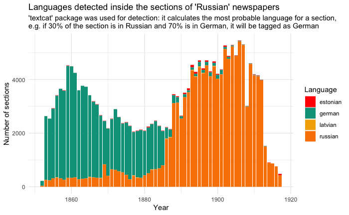

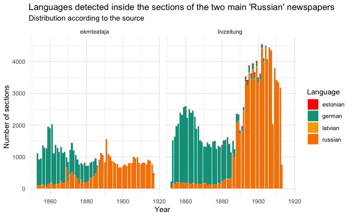

Very rough scaling of the length of a section and further plot:

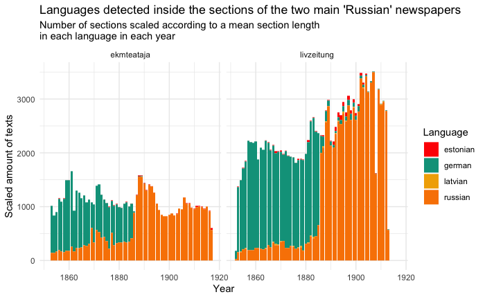